# 1. Download the “Sunny Lake” image.

# 8. Filter these images using low-pass filters with kernels presented on pages 9 and 12 of “filter.pdf” document. Comment on the results.

```python
img = temp_image.astype(np.uint8)
img = img[:256, :256]
```

```python
r = 50 # how narrower the window is
ham = np.hamming(256)[:,None] # 1D hamming
ham2d = np.sqrt(np.dot(ham, ham.T)) ** r # expand to 2D hamming

f = cv2.dft(img.astype(np.float32), flags=cv2.DFT_COMPLEX_OUTPUT)
f_shifted = np.fft.fftshift(f)
f_complex = f_shifted[:,:,0]*1j + f_shifted[:,:,1]
f_filtered = ham2d * f_complex
```

```python
f_filtered_shifted = np.fft.fftshift(f_filtered)
inv_img = np.fft.ifft2(f_filtered_shifted) # inverse F.T.
filtered_img = np.abs(inv_img)
filtered_img -= filtered_img.min()
filtered_img = filtered_img*255 / filtered_img.max()
filtered_img = filtered_img.astype(np.uint8)
```

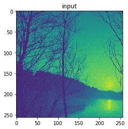

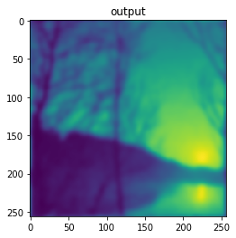

```python
plt.imshow(img)
plt.title('input')
plt.show()

plt.imshow(filtered_img)
plt.title('output')
plt.show()
```

# 9. Filter images in 7) using high-pass filters with kernels presented on pages 17 and 19 of “filter.pdf” document. Comment on the results.

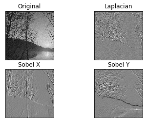

```python
import numpy as np
import cv2 as cv
from matplotlib import pyplot as plt
img = temp_image.astype(np.uint8)
img = img[:256, :256]
laplacian = cv.Laplacian(img,cv.CV_64F)
sobelx = cv.Sobel(img,cv.CV_64F,1,0,ksize=5)
sobely = cv.Sobel(img,cv.CV_64F,0,1,ksize=5)
plt.subplot(2,2,1),plt.imshow(img,cmap = 'gray')
plt.title('Original'), plt.xticks([]), plt.yticks([])
plt.subplot(2,2,2),plt.imshow(laplacian,cmap = 'gray')
plt.title('Laplacian'), plt.xticks([]), plt.yticks([])
plt.subplot(2,2,3),plt.imshow(sobelx,cmap = 'gray')
plt.title('Sobel X'), plt.xticks([]), plt.yticks([])
plt.subplot(2,2,4),plt.imshow(sobely,cmap = 'gray')
plt.title('Sobel Y'), plt.xticks([]), plt.yticks([])
plt.show()
```

# 10. Inspect Figure-1. Comment on the type of noise and propose a method to de-noise the image. Implement your method and present the de-noised image.

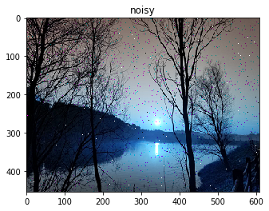

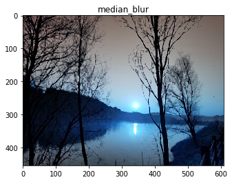

```python
import numpy as np
import cv2

pathname = '/Users/erkamozturk/Desktop/hw1/Figure_1.png'
img = cv2.imread(pathname, 1)
row,col,ch = img.shape
p = 0.5
a = 0.009
noisy = img

  # Salt mode
num_salt = np.ceil(a * img.size * p)
coords = [np.random.randint(0, i - 1, int(num_salt))
          for i in img.shape]
noisy[coords] = 1

  # Pepper mode
num_pepper = np.ceil(a * img.size * (1. - p))
coords = [np.random.randint(0, i - 1, int(num_pepper))
          for i in img.shape]
noisy[coords] = 0

#cv2.imshow('noisy', noisy)

plt.imshow(noisy)
plt.title('noisy')
plt.show()

#%%
median_blur= cv2.medianBlur(noisy, 3)

#cv2.imshow('median_blur', median_blur)

plt.imshow(median_blur)
plt.title('median_blur')
plt.show()
```